# 04: Regression Models

General Overview

Dean Adams, Iowa State University

# Regression

A linear model where the response variable $\small\mathbf{Y}$ is continuous, and $\small\mathbf{X}$ contains one or more continuous covariates (predictor variables)

$$\mathbf{Y}=\mathbf{X}\mathbf{\beta }
+\mathbf{E}$$

- $\small{H}_{0}$: No covariation between $\small\mathbf{Y}$ & $\small\mathbf{X}$. More formally, variation in $\small\mathbf{Y}$ is not explained by $\small\mathbf{X}$: i.e., $\small{H}_{0}$: $\small{SS}_{X}\sim{0}$
- $\small{H}_{1}$: Difference covariation is present between $\small\mathbf{Y}$ & $\small\mathbf{X}$. More formally, some variation in $\small\mathbf{Y}$ *is* explained by $\small\mathbf{X}$: i.e., $\small{H}_{1}$: $\small{SS}_{X}>0$
- Parameters: model coefficients $\small\hat\beta$ represent slopes describing the relationship between $\small\mathbf{Y}$ & $\small\mathbf{X}$
- Model written as: $\small{Y}=\beta_{0}+X_{1}\beta_{1}+\epsilon$

# Assumptions of Regression

1: Independence: $\small\epsilon_{ij}$ of objects must be independent

2: Normality: requires normally distributed $\small\epsilon_{ij}$

3: Homoscedasticity: equal variance

4: $\small{X}$ values are independent and measured without error

# General Computations

- Fit line that minimizes sum of squared deviations (LS fit) from $\small{Y}$-variates to line (vertical deviations b/c no error in $\small{X}$)
- Slope calculated as: $\small{\beta}_{1}=\beta_{YX}=\frac{\sum\left(X-\overline{X}\right)\left(Y-\overline{Y}\right)}{\sum\left(X-\overline{X}\right)^{2}}$
- Regression line always crosses $\small{\left(\overline{X},\overline{Y}\right)}$ so intercept is: $\small{\beta}_{0}=\overline{Y}-\beta_{1}\overline{X}$

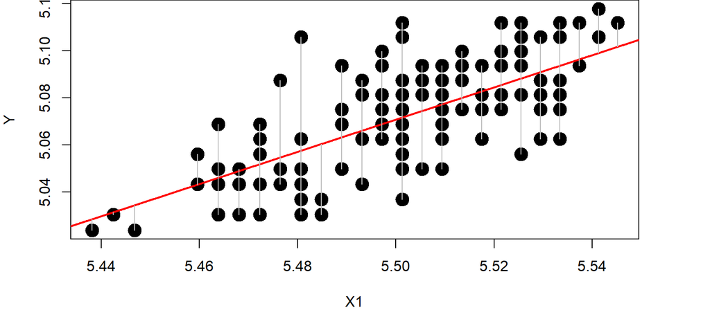

# Computations: Sums-of-Squares

- SS explained by the model: $\small{SSM}=\sum\left(\hat{Y}-\overline{Y}\right)^{2}$
- SS residual error: $\small{SSE}=\sum\left(Y_{i}-\hat{Y}\right)^{2}$
- Convert to variances (mean squares), calculate $\small{F}$ and assess significance with ($\small{df}_{1},df_{2}$)

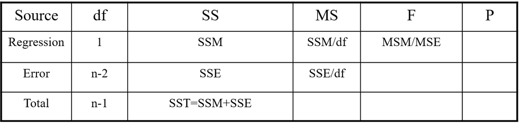

- Note: in future weeks we will use matrix algebra to obtain $\small{SS}$ for model effects ($\small{SSM}$, $\small{SSE}$, etc.)

# Assessing Significance

- Standard approach:
  - Compare $\small{F}$-ratio to $\small{F}$-distribution with appropriate $\small{df}$

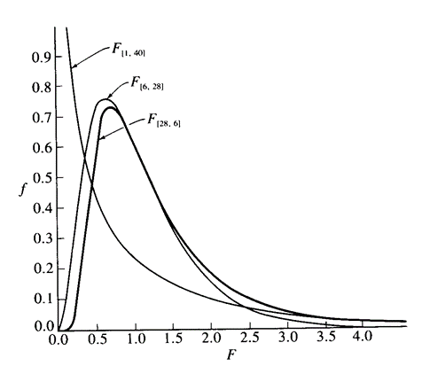

- Resampling Alternative:
  - Shuffle $\small{Y}$ and generate distribution of possible $\small{F}$-values (note: for single-factor regression, shuffling individuals IS a residual randomization)

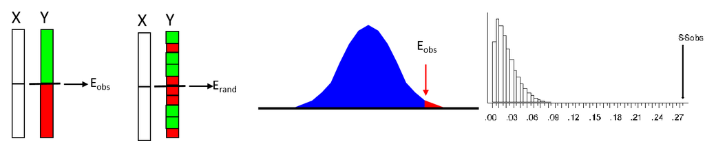

# Regression: Parameter Tests

- $\small{F}$-test assesses variance explained, but not how much $\small{Y}$ changes with $\small{X}$
- Can evaluate the model parameters separately
- Slope test ($\small{\beta}_{1}\neq0$): $\small{t}=\frac{\beta_{1}-0}{s_{\beta_{1}}}$ with $\tiny{s}_{\beta_{1}}=\sqrt{\frac{MSE}{\sum\left(X_{i}-\overline{X}\right)^{2}}}$ & $\tiny{n-2}$ $\small{df}$
- Intercept test ($\small{\beta}_{0}\neq0$): $\small{t}=\frac{\beta_{0}-0}{s_{\beta_{0}}}$ with $\tiny{s}_{\beta_{0}}=\sqrt{MSE\Big[\frac{1}{n}+\frac{\overline{X}^{2}}{\sum\left(X_{i}-\overline{X}\right)^{2}}\Big]}$ & $\tiny{n-2}$ $\small{df}$
- Can also test against particular values (e.g,. Isometry: is $\small\beta_{1}=1$?)
- Very useful for certain biological hypotheses

# Regression Example: Bumpus Data

- Are total length and alar extent associated in sparrows?

```r
model1<-lm(Y~X1)
anova(model1)
```

```
## Analysis of Variance Table
##
## Response: Y
##            Df   Sum Sq  Mean Sq F value    Pr(>F)
## X1          1 0.032412 0.032412  124.01 < 2.2e-16 ***
## Residuals 134 0.035023 0.000261
## ---
## Signif. codes:  0 '***' 0.001 '**' 0.01 '*' 0.05 '.' 0.1 ' ' 1
```

```r
model1$coefficients
```

```
## (Intercept)          X1
##   1.3044593   0.6847984
```

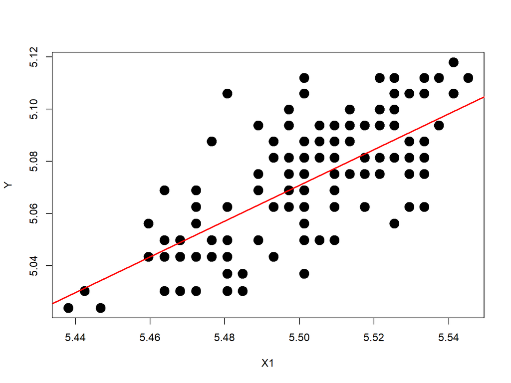

- Yes. Total length and alar extent covary in sparrows

# Regression Example: Permutations

```r
model2 <- lm.rrpp(Y~X1, print.progress = FALSE, data = mydat)
anova(model2)$table
```

```
##            Df       SS       MS     Rsq      F      Z Pr(>F)
## X1          1 0.032412 0.032412 0.48063 124.01 5.9368  0.001 **
## Residuals 134 0.035023 0.000261 0.51937
## Total     135 0.067435
## ---
## Signif. codes:  0 '***' 0.001 '**' 0.01 '*' 0.05 '.' 0.1 ' ' 1
```

```r
coef(model2)
```

```
##                  [,1]
## (Intercept) 1.3044593
## X1          0.6847984
```

- Results are identical to parametric solution

# Regression Vs. Correlation

- Correlation and regression are closely linked
- Mathematically: $\small\beta_{YX}=\frac{\sum\left(X-\overline{X}\right)\left(Y-\overline{Y}\right)}{\sum\left(X-\overline{X}\right)^{2}}$ vs. $\small{r}_{YX}=\frac{\sum\left(X-\overline{X}\right)\left(Y-\overline{Y}\right)}{\sqrt{\sum(X-\bar{X})^2\sum(Y-\bar{Y})^2}}$
- The difference is in the denominator:
- $\small{r}$ is a *standardized* regression coefficient (i.e. slope in standard deviation units)
- $\small{\beta}$: error in $\small{Y}$ direction only (direction of scatter)
- $\small{r}$: error in $\small{X}$ & $\small{Y}$ (dispersion of scatter)
- Thus, regression models causation ($\small{Y}$ as function of $\small{X}$) and correlation models association (covariation in $\small{X}$ & $\small{Y}$)

# Regression Vs. Correlation

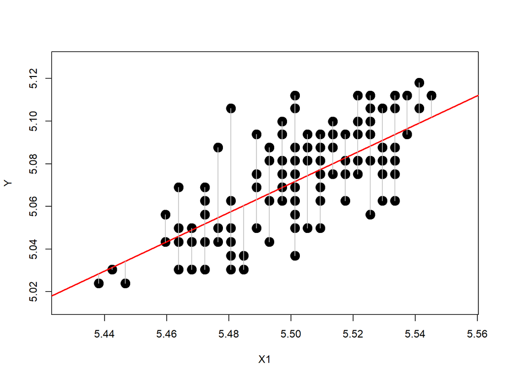

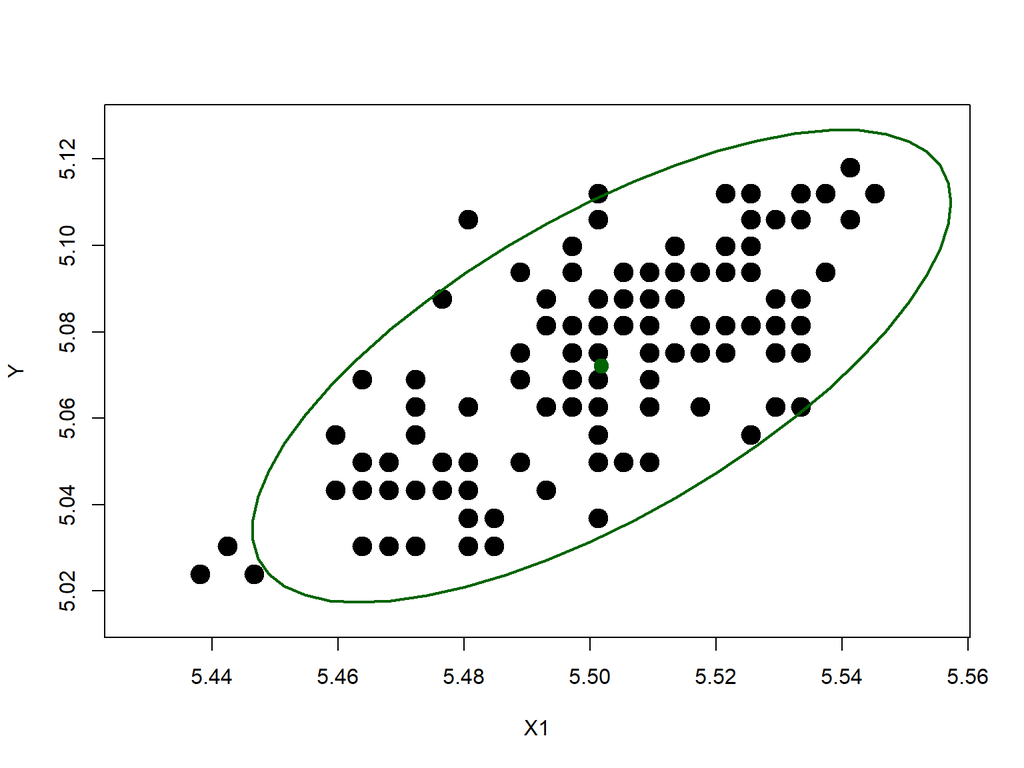

# Model II Regression: Error in Y & X

- When both $\small{X}$ & $\small{Y}$ contain measurement error, model I regression underestimates slope
- Model II regression accounts for this by minimizing deviations perpendicular to regression line (not in $\small{Y}$ direction only)
- Different types of model II regression, depending on data (major axis, reduced major axis, etc.)
- $\small{X}$ & $\small{Y}$ in ‘same’ units/scale: major axis regression (PCA)
- $\small{X}$ & $\small{Y}$ not in same units/scale: standard (reduced) major axis regression

# Model II Regression

- When $\small{X}$ & $\small{Y}$ in ‘same’ units/scale: *major axis* regression (PCA)
  - Compute covariance matrix for X & Y: $\small{S}_{XY}=\left[ {\begin{array}{cc} s^{2}_{X} & s_{XY} \\ s_{XY} & s^{2}_{Y} \\ \end{array} } \right]$
  - Obtain principle eigenvalue $\tiny{\lambda}_{1}=0.5*\left({s^{2}_{X}+s^{2}_{Y}+\sqrt{\left(s^{2}_{X}+s^{2}_{Y}\right)^{2}-4\left(s^{2}_{X}s^{2}_{Y}-s^{2}_{XY}\right)}}\right)$ and associated eigenvector
  - Slope is: $\small{\beta}_{YX}=\frac{s_{XY}}{\lambda_{1}-s^{2}_{X}}$
- When $\small{X}$ & $\small{Y}$ not in same units/scale: use standard *(reduced) major axis* regression
  - Standardize variables to $\small{N}\left(0,1\right)$ (i.e., convert to standard normal deviates)
  - Calculate SMA slope as: $\small{\beta}_{YX_{RMA}}=\frac{\beta_{YX}}{r_{YX}}$

# Model II Regression: Example

```
## RMA was not requested: it will not be computed.
```

```
##   Method  Intercept     Slope Angle (degrees) P-perm (1-tailed)
## 1    OLS  1.3044593 0.6847984        34.40328             0.001
## 2     MA -0.3329159 0.9824064        44.49152             0.001
## 3    SMA -0.3624212 0.9877692        44.64746                NA
```

```
##   Method 2.5%-Intercept 97.5%-Intercept 2.5%-Slope 97.5%-Slope
## 1    OLS      0.6352913       1.9736273  0.5631720   0.8064248
## 2     MA     -1.3892010       0.5532596  0.8213358   1.1743959
## 3    SMA     -1.0726264       0.2656984  0.8736027   1.1168556
```

```
## RMA was not requested: it will not be computed.
```

```
## No permutation test will be performed
```

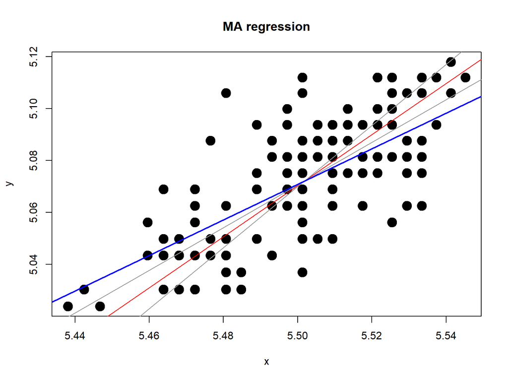

# Model II Regression: Comments

- Justification for using model II regression has been overplayed in biology
- What matters is *NOT* whether $\small{X}$ has measurement error: $\small{s^{2}_{\epsilon_{X}}}$
- Instead, ONLY when $\small{s^{2}_{\epsilon_{X}}} / s^{2}_{X}$ is large, might there be an issue with Model I regression.
  - But even in this case, RMA is not guaranteed to alleviate the problem. (see Kilmer & Rodriguez, 2017)
- Also, model II regression is strongly biased, because it confounds biological variation and measurement error (see Hansen and Bartoszek 2012)

#### Conclusion: Model I regression is preferred

# Multiple Regression

- Predict $\small{Y}$ using several $\small{X}$ variables simultaneously
- Model: $\small{Y}=\beta_{0}+X_{1}\beta_{1}+X_{2}\beta_{2}+\dots+\epsilon$
- $\small{\beta}_{i}$ are partial regression coefficients (effect of $\small{X}_{i}$ while holding effects of other $\small{X}$ constant)
- For 2 $\small{X}$ variables, think of fitting a plane to the data

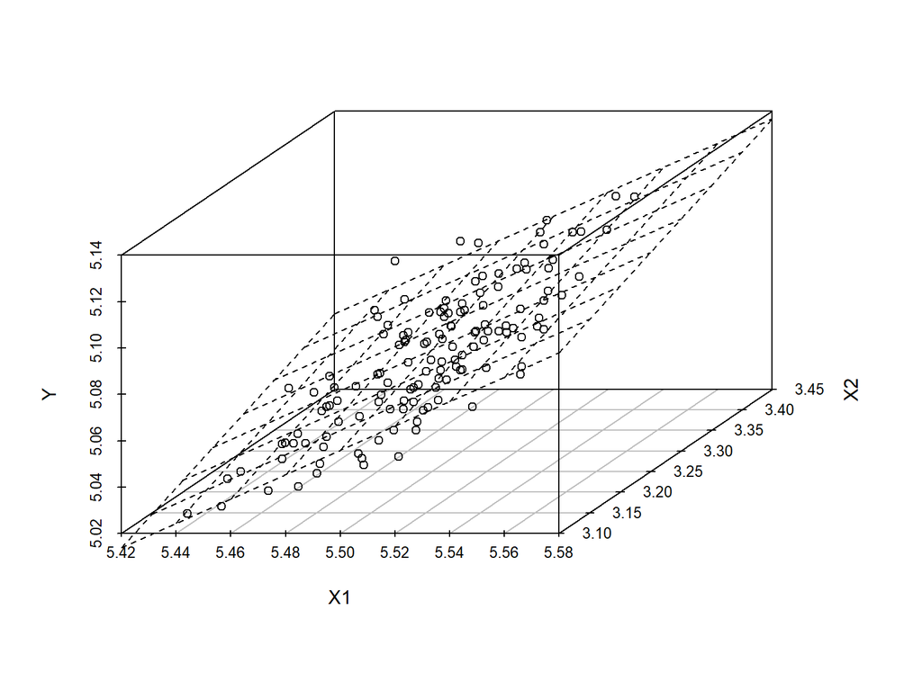

###### NOTE: One must consider *multicollinearity*: the correlation of $\small{X}$ variables with one another. This can affect statistical inference.

# Multiple Regression Coefficients

- Standard partial regression coefficients $\small{\beta^{'}_{YX_{i}\cdot{X}_{j}}}$ describe relationship of $\small{Y}$ & $\small{X}_{i}$ while holding effect of $\small{X}_{j}$ constant
  - Expresses change in normalized units, i.e., as standard normal deviates $\small\frac{Y-\overline{Y}}{s_{Y}}$
  - ADVANTAGE: can be directly compared for each variable
  - Found from variable correlations: $\small{\beta^{'}_{YX_{1}\cdot{X}_{2}}}=\frac{r_{X_{1}Y}-r_{X_{2}Y}r_{X_{1}X_{2}}}{1-r^{2}_{X_{1}X_{2}}}$
- Interpret, then calculate back to original units and for conventional partial regression coefficients: $\small{\beta_{YX_{1}\cdot{X}_{2}}}=\beta^{'}_{YX_{1}\cdot{X}_{2}}\frac{s_{Y}}{s_{X1}}$

# Multiple Regression: Example

```r
anova(lm(Y~X1+X2))
```

```
## Analysis of Variance Table
##
## Response: Y
##            Df   Sum Sq  Mean Sq F value    Pr(>F)
## X1          1 0.032412 0.032412 137.118 < 2.2e-16 ***
## X2          1 0.003585 0.003585  15.168 0.0001551 ***
## Residuals 133 0.031438 0.000236
## ---
## Signif. codes:  0 '***' 0.001 '**' 0.01 '*' 0.05 '.' 0.1 ' ' 1
```

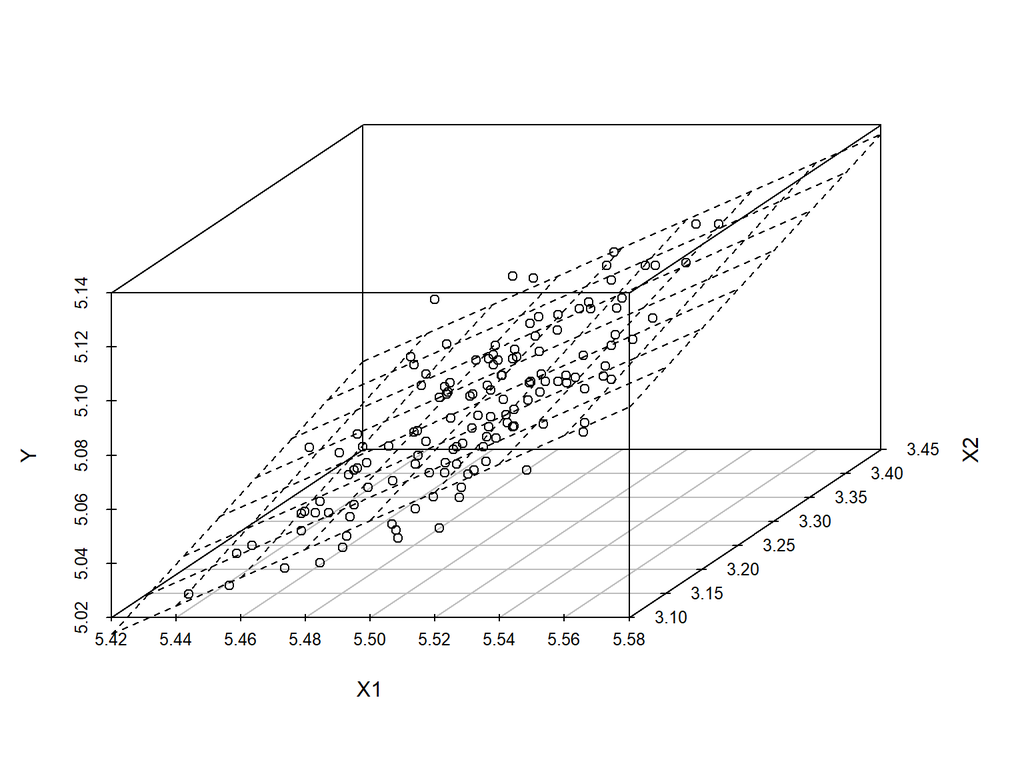

# Multiple Regression: Permutation

```r
anova(lm.rrpp(Y~X1+X2,print.progress = FALSE, data=mydat))$table
```

```
##            Df       SS       MS     Rsq       F      Z Pr(>F)
## X1          1 0.032412 0.032412 0.48063 137.118 6.1079  0.001 **
## X2          1 0.003585 0.003585 0.05317  15.168 2.9586  0.001 **
## Residuals 133 0.031438 0.000236 0.46620
## Total     135 0.067435
## ---
## Signif. codes:  0 '***' 0.001 '**' 0.01 '*' 0.05 '.' 0.1 ' ' 1
```

```r
  cor(X1,X2)
```

```
## [1] 0.573966
```

- Because of multicollinearity, one might consider type II SS here

```r
anova(lm.rrpp(Y~X1+X2,print.progress = FALSE, data=mydat,SS.type = "II"))$table
```

```
##            Df       SS        MS     Rsq      F      Z Pr(>F)
## X1          1 0.012782 0.0127819 0.18954 54.074 4.4652  0.001 **
## X2          1 0.003585 0.0035853 0.05317 15.168 2.9586  0.001 **
## Residuals 133 0.031438 0.0002364 0.46620
## Total     135 0.067435
## ---
## Signif. codes:  0 '***' 0.001 '**' 0.01 '*' 0.05 '.' 0.1 ' ' 1
```

# Multiple Regression: Adding Additional Explanatory Variables

- For all models, $\small{R}^{2}$ is the proportion of variation explained by model
  - By definition, as the number of $\small{X}$ variables increases, $\small{R}^{2}$ increases (at worst, a new variable contributes no additional information, but it can never decrease the variation explained by the simpler model)
- Should I add another variable to my model?
  - Different approaches: stepwise addition, stepwise deletion, random addition,etc.
    - Adjusted $\small{R}^{2}$ can be used to compare models (though *AIC* is far more common)
- **Important related topic**: model comparison. Which explanatory model best explains variation in $\small{Y}$? We discuss this topic later in the semester

###### CAREFUL WITH BIOLOGICAL INTERPRETATION!!! One can over-fit models, or identify a best fitting model (in terms of some) that is biologically nonsensical

# Comparing Regression Lines

- Say one has two regressions (e.g., allometry patterns in each of two species). Can I compare these trends?
- To compare the slopes of two regression lines, calculate an $\small{F}$-ratio as:

$$\tiny{F}=\frac{\left(\beta_{1}-\beta_{2}\right)^{2}}{\overline{s}^{2}_{YX}\frac{\sum\left(X_{1}-\overline{X}_{1}\right)^{2}+\sum\left(X_{2}-\overline{X}_{2}\right)^{2}}{\sum\left(X_{1}-\overline{X}_{1}\right)^{2}\sum\left(X_{2}-\overline{X}_{2}\right)^{2}}}$$

Where $\small{\overline{s}_{YX}}$ is the weighted average of $\small{s}_{YX}$, and $\small{df}=1,(n_{1}+n_{2}-4)$

Procedure can be generalized to compare > 2 regression lines (see *Biometry*)

# ANCOVA: Analysis of Covariance

- ANCOVA is a linear model containing *both* a categorical and a continuous $\small{X}$ explanatory variable (i.e., a ‘combination’ of ANOVA and regression)
- $\small{H}_{0}$: no differences among slopes, no differences among groups
- Must first compare slopes, then compare groups (ANOVA) while holding effects of covariate constant
- Several possible outcomes to ANCOVA

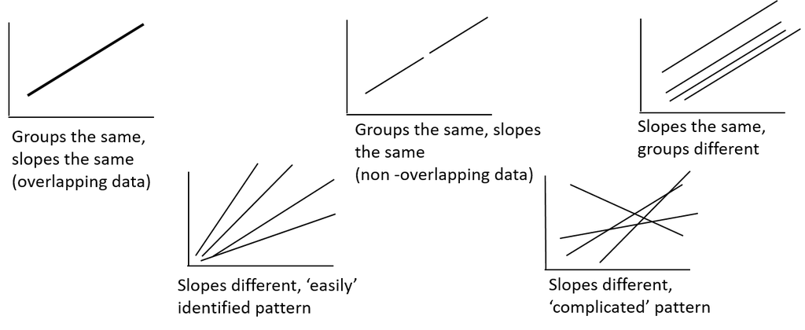

# ANCOVA: Computations

- Model: $\small{Y}=\beta_{0}+X_{cov}\beta_{1}+X_{gp}\beta_{2}+X_{cov:gp}\beta_{3}+\epsilon$

###### Note: Factors with 3+ groups will have multiple $\small\beta$ per factor.

- Calculate $\small{SS}$ for the following model effects:

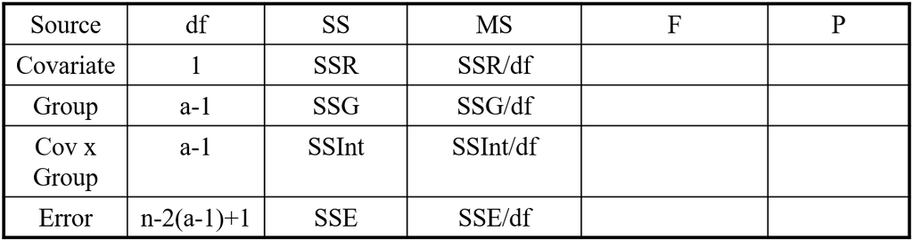

###### NOTE: If interaction term *not* significant (i.e., no evidence of heterogeneous slopes), remove interaction and re-evaluate $\small{Y}$ using a common slopes model to compare least-squares group means (while accounting for covariate)

# Model Parameters ($\beta$)

$\beta$ contains components of adjusted least-squares (LS) means and group slopes

```r
y <- c(6, 4, 0, 2, 3, 3, 4, 7 )
x <- c(7,8,2,3,5,4,3,6)
gp <- factor(c(1,1,1,1,2,2,2,2));
df <- data.frame(x = x, y = y, gp = gp)

fit <- lm(y~x*gp, data = df); coef(fit)
```

```
## (Intercept)           x         gp2       x:gp2
##  -0.8461538   0.7692308   1.0461538   0.1307692
```

```r
# gp 2 coefficients
c(coef(fit)[1]+coef(fit)[3], coef(fit)[2]+coef(fit)[4])
```

```
## (Intercept)           x
##         0.2         0.9
```

```r
res.gp <- by(df, gp, function(x) lm(y~x, data = x))
sapply(res.gp, coef)
```

```
##                      1   2
## (Intercept) -0.8461538 0.2
## x            0.7692308 0.9
```

# Assessing Significance

- Standard approach:
  - Compare $\small{F}$-ratio to $\small{F}$-distribution with appropriate $\small{df}$

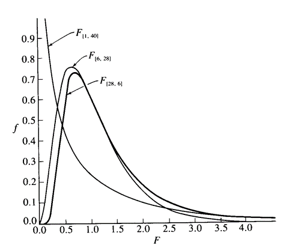

- Resampling Alternative: - Residual randomization: Permute *residuals* $\mathbf{E}_{R}$ from reduced model $\small\mathbf{X}_{R}$ for each model effect to generate empirical sampling distribution of possible $\small{F}$-values - Evaluates $\small{SS}_{\mathbf{X}_{F}}$ while holding effects of $\small\mathbf{X}_{R}$ constant

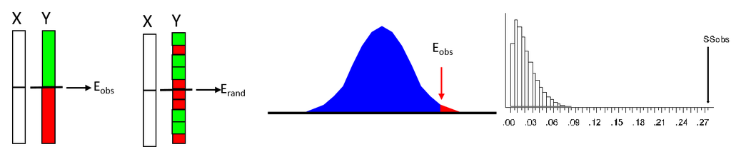

# ANCOVA: What are We Doing?

- ANCOVA explicitly evaluates a series of sequential hypotheses
- 1: Are slopes for groups different? ($\small{SS}_{cov:group} > 0$?)
  - If interaction significant, then we *cannot* compare group means, because slopes differ among groups
  - Thus, pairwise comparisons *must* be of the slopes themselves (i.e., comparing the within-group covariation patterns to one another)
- 2: If the cov:gp interaction is *NOT* significant, we remove that effect and fit a common slopess model:‘Y~cov + group’. This evaluates whether the adjusted LS-means for the groups differ while accounting for a common covariate

###### NOTE: In the former case (i.e., a significant cov:group interaction), our hypothesis has often been changed by the data. That is, we may have initiated the analysis as “Are the groups different even when I account for X?” but our data have told us that we instead must focus on the slope differences among groups, not differences among group means!

# ANCOVA: Example

- Do groups of sparrows differ from one another in total length while accounting for body weight?

```r
anova(lm(Y~X2*SexBySurv))
```

```
## Analysis of Variance Table
##
## Response: Y
##               Df   Sum Sq   Mean Sq F value    Pr(>F)
## X2             1 0.023215 0.0232149 77.3890 8.139e-15 ***
## SexBySurv      3 0.005172 0.0017239  5.7467  0.001014 **
## X2:SexBySurv   3 0.000651 0.0002172  0.7239  0.539496
## Residuals    128 0.038397 0.0003000
## ---
## Signif. codes:  0 '***' 0.001 '**' 0.01 '*' 0.05 '.' 0.1 ' ' 1
```

- Note interaction term is not significant. Fit common slopes model and compare adjusted-LS group means

# ANCOVA: Example Cont.

```r
anova(lm(Y~X2+SexBySurv))  # COMMON SLOPES MODEL
```

```
## Analysis of Variance Table
##
## Response: Y
##            Df   Sum Sq   Mean Sq F value    Pr(>F)
## X2          1 0.023215 0.0232149 77.8814 6.015e-15 ***
## SexBySurv   3 0.005172 0.0017239  5.7833 0.0009591 ***
## Residuals 131 0.039048 0.0002981
## ---
## Signif. codes:  0 '***' 0.001 '**' 0.01 '*' 0.05 '.' 0.1 ' ' 1
```

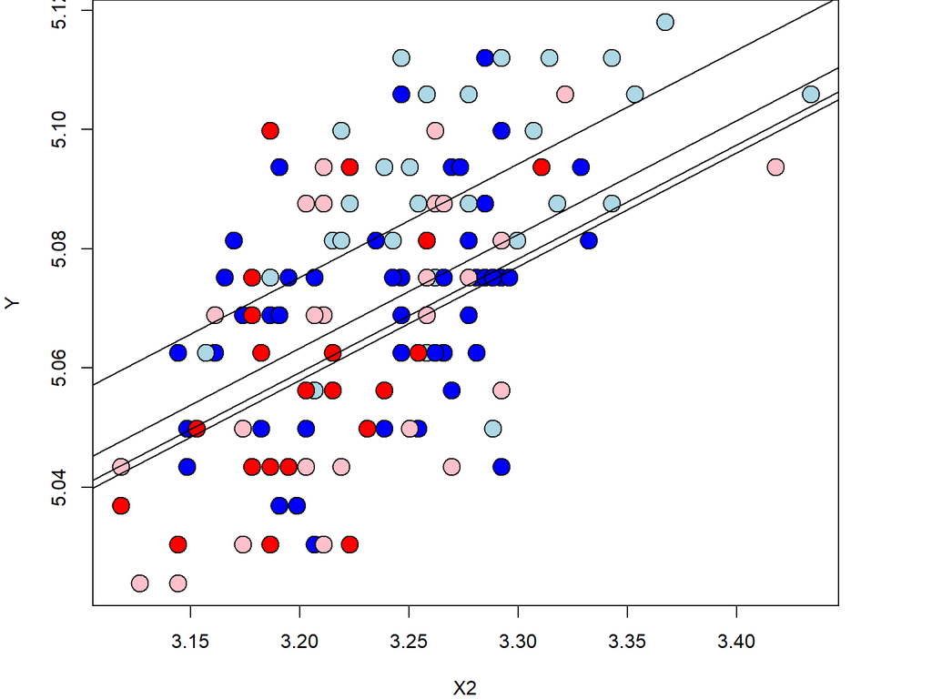

- There is evidence of group differences while accounting for body weight

# ANCOVA: Pairwise Comparisons

- When there is a significant common slopes model, one wishes to evaluate *which* groups differ from one another. Pairwise comparisons may be utilized, but based on the **fitted values** of the model (these are the values that account for the covariate)

```r
pairwise.t.test(model.ancova$fitted.values, SexBySurv, p.adj = "none")
```

```
##
##  Pairwise comparisons using t tests with pooled SD
##
## data:  model.ancova$fitted.values and SexBySurv
##
##         f FALSE f TRUE  m FALSE
## f TRUE  0.028   -       -
## m FALSE 4.2e-15 < 2e-16 -
## m TRUE  0.029   1.6e-05 1.0e-12
##
## P value adjustment method: none
```

# ANCOVA via Permutation

- All of the above computations may be evaluated using RRPP

```r
model.anc2 <- lm.rrpp(Y~X2*SexBySurv, print.progress = FALSE, data = mydat)
anova(model.anc2)$table
```

```
##               Df       SS        MS     Rsq       F       Z Pr(>F)
## X2             1 0.023215 0.0232149 0.34426 77.3890  5.2846  0.001 **
## SexBySurv      3 0.005172 0.0017239 0.07669  5.7467  3.0048  0.002 **
## X2:SexBySurv   3 0.000651 0.0002172 0.00966  0.7239 -0.0862  0.530
## Residuals    128 0.038397 0.0003000 0.56939
## Total        135 0.067435
## ---
## Signif. codes:  0 '***' 0.001 '**' 0.01 '*' 0.05 '.' 0.1 ' ' 1
```

```r
model.anc3 <- lm.rrpp(Y~X2+SexBySurv, print.progress = FALSE, data = mydat)
anova(model.anc3)$table
```

```
##            Df       SS        MS     Rsq       F      Z Pr(>F)
## X2          1 0.023215 0.0232149 0.34426 77.8814 5.2836  0.001 **
## SexBySurv   3 0.005172 0.0017239 0.07669  5.7833 3.0176  0.002 **
## Residuals 131 0.039048 0.0002981 0.57905
## Total     135 0.067435
## ---
## Signif. codes:  0 '***' 0.001 '**' 0.01 '*' 0.05 '.' 0.1 ' ' 1
```

- ANCOVA results analogous to those from parametric evaluation

# Pairwise Tests via Permutation

- With RRPP, one can perform pairwise comparisons of adjusted LS-group means.

```r
res <- summary(pairwise(model.anc3, groups = SexBySurv), test.type = "dist", stat.table = FALSE)
```

```
##             f FALSE      f TRUE    m FALSE      m TRUE
## f FALSE 0.000000000 0.001283828 0.01595601 0.004128217
## f TRUE  0.001283828 0.000000000 0.01723984 0.005412045
## m FALSE 0.015956012 0.017239840 0.00000000 0.011827794
## m TRUE  0.004128217 0.005412045 0.01182779 0.000000000
```

```
##            f FALSE     f TRUE  m FALSE    m TRUE
## f FALSE  0.0000000 -0.9612166 2.772571 0.4670408
## f TRUE  -0.9612166  0.0000000 2.578038 0.6999764
## m FALSE  2.7725709  2.5780381 0.000000 2.3954073
## m TRUE   0.4670408  0.6999764 2.395407 0.0000000
```

```
##         f FALSE f TRUE m FALSE m TRUE
## f FALSE   1.000  0.819   0.002  0.337
## f TRUE    0.819  1.000   0.002  0.256
## m FALSE   0.002  0.002   1.000  0.002
## m TRUE    0.337  0.256   0.002  1.000
```

# Pairwise Tests via Permutation Cont.

```r
PW <- pairwise(model.anc3, groups = SexBySurv)
summary(PW, test.type = "VC", angle.type = "deg")
```

```
##
## Pairwise comparisons
##
## Groups: f FALSE f TRUE m FALSE m TRUE
##
## RRPP: 1000 permutations
##
## LS means:
## Vectors hidden (use show.vectors = TRUE to view)
##
## Pairwise statistics based on mean vector correlations
##                 r angle    UCL (95%)          Z Pr > angle
## f FALSE:f TRUE  1     0 8.537736e-07 -0.4814688     0.5955
## f FALSE:m FALSE 1     0 8.537736e-07 -0.4969422     0.6005
## f FALSE:m TRUE  1     0 8.537736e-07 -0.4889152     0.5980
## f TRUE:m FALSE  1     0 8.537736e-07 -0.4727927     0.5930
## f TRUE:m TRUE   1     0 8.537736e-07 -0.4735833     0.5930
## m FALSE:m TRUE  1     0 8.537736e-07 -0.5034108     0.6020
```

###### NOTE: For illustrative purposes only, as this particular example did *not* display a significant cov:group interaction

# ANCOVA: Common Errors

- 1: Perform ANOVA on regression residuals: NOT the same as ANCOVA (different $\small{df}$, different pooled $\small{\beta}$, etc.). Also, lose test of slopes, which is important (see J. Anim. Ecol. 2001. 70:708-711)
- 2: Significant cov:group interaction, but still compare groups: not useful, as answer depends upon where along regression you compare
- 3: “Size may be a covariate, so I’ll use a small size range to ‘standardize’ for it”: choosing animals of similar sizes will eliminate covariate, but also will eliminate potentially important biological information (e.g., what if male head width grows relatively faster than females (i.e. size:head interaction?)

# Other Regression Models

- Multiple regression models the case where all independent $\small{X}$ variables affect $\small{Y}$ independently:

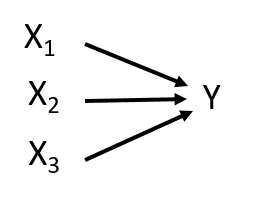

- However, one could have dependent-relationships among $\small{X}$ variables

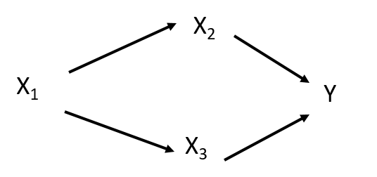

- **Path Analysis** & **Structural Equation Modeling** can be used in such circumstances